# Introduction to sshist

| Function | Estimator | Dimension | Bandwidth |
| --- | --- | --- | --- |
| `sshist` | Histogram | 1D | Fixed (single bin width) |
| `sshist_2d` | Histogram | 2D | Fixed per axis |
| `sskernel` | Kernel density | 1D | Fixed global |
| `ssvkernel` | Kernel density | 1D | Locally adaptive (Abramson) |
| `sskernel2d` | Kernel density | 2D | Fixed global (isotropic) |
| `ssvkernel2d` | Kernel density | 2D | Locally adaptive (Abramson) |

These methods are particularly useful when data exhibits multimodal structure, because naive rules (Sturges, Freedman–Diaconis) tend to over- or under-smooth.

*Note: The package supports OpenMP C++ multithreading and parallel bootstrapping out of the box. For CRAN compliance, it defaults to 1 core. You can globally increase this by setting the option below.*

```r
library(sshist)
options(sshist.ncores = 2) # Use 2 cores for vignette building
```

## 1. Optimal 1D Histogram: `sshist`

The `sshist` function performs an exhaustive search over candidate bin counts to find the optimal bin width that minimizes the MISE cost function.

**Complete Parameter List:**

- `x`: Numeric vector of data points. Missing values (`NA`) are automatically removed.
- `n_max`: Integer or `NULL`. Maximum number of bins to consider. If `NULL`, it is determined automatically based on data resolution to prevent comb artifacts.
- `sn`: Integer. Number of histogram shifts used for the shift-average estimation (default `30`).
- `ncores`: Integer. Number of OpenMP threads to use for the C++ cost calculation (default `1` or via `getOption("sshist.ncores")`).

### Comparison with the standard approach

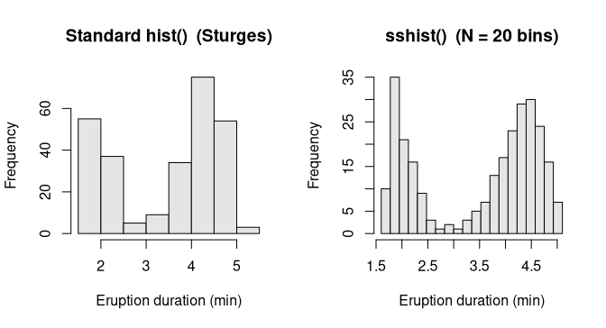

```r
data(faithful)
x_data <- faithful$eruptions

oldpar <- par(mfrow = c(1, 2))

# Standard R histogram (Sturges rule)
hist(x_data,
     main = "Standard hist()  (Sturges)",
     xlab = "Eruption duration (min)", col = "grey90")

# Shimazaki-Shinomoto optimal histogram
res <- sshist(x_data)
hist(x_data, breaks = res$edges,
     main = paste0("sshist()  (N = ", res$opt_n, " bins)"),
     xlab = "Eruption duration (min)", col = "grey90")
```

```r
par(oldpar)
```

### The S3 object

`sshist()` returns an object of class `"sshist"`. The `plot()` method draws the optimal histogram with a data rug.

```r
print(res)
```

```
#> Shimazaki-Shinomoto Histogram Optimization
#> ------------------------------------------
#> Optimal Bins (N): 20
#> Bin Width (D):    0.175
```

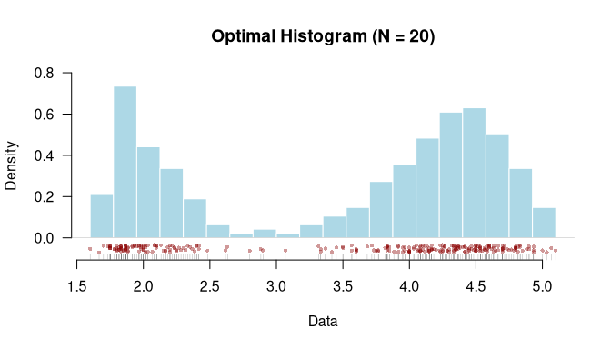

```r
plot(res)
```

## 2. Optimal 1D Kernel Density: `sskernel` & `ssvkernel`

For smooth continuous distributions, `sskernel` evaluates a single fixed global bandwidth, while `ssvkernel` computes locally adaptive bandwidths based on Abramson’s square-root scaling law. Both use a fast FFT implementation.

**Complete Parameter List:**

- `x`: Numeric vector of sample data.
- `tin`: Optional numeric vector specifying the grid of evaluation points. If `NULL`, a grid is generated automatically.
- `W` *(sskernel only)*: Optional numeric vector of bandwidths to evaluate. If provided, the internal grid search is skipped.
- `M` *(ssvkernel only)*: Integer. Number of bandwidths to examine during the adaptive process (default `80`).
- `WinFunc` *(ssvkernel only)*: Character string specifying the window function for local weights. Options: `"Gauss"`, `"Boxcar"` (default), `"Laplace"`, or `"Cauchy"`.
- `nbs`: Integer. Number of bootstrap samples for calculating confidence intervals. Set to `0` to skip (default `0`).
- `ncores`: Integer. Number of CPU cores to use for parallel bootstrapping (default 1L or via getOption(`"sshist.ncores"`, 1L)).

### Fixed Global Bandwidth (`sskernel`)

Estimates a 1D density using a Gaussian kernel with the globally optimal bandwidth.

```r
res_k <- sskernel(x_data)
print(res_k)
```

```
#> Shimazaki-Shinomoto Kernel Density Estimation
#> ----------------------------------------------
#> Optimal Bandwidth: 0.1103
#> Grid Points:       1000
```

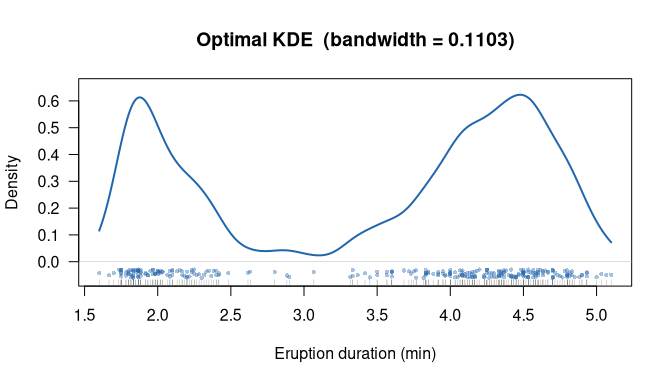

```r
plot(res_k, xlab = "Eruption duration (min)")
```

### Locally Adaptive Bandwidth (`ssvkernel`)

Uses a stiffness parameter `gamma` (optimized via MISE) to control how much the bandwidth can vary locally. A Nadaraya–Watson smoother with the selected window function (`WinFunc`) stabilizes the bandwidth sequence.

```r
res_sv <- ssvkernel(x_data)
print(res_sv)
```

```
#> Shimazaki-Shinomoto Adaptive Kernel Density Estimation
#> -------------------------------------------------------
#> Optimal Stiffness (gamma): 1
#> Grid Points:               1000
#> Bandwidth Range:           0.04199282 -- 0.2519655
```

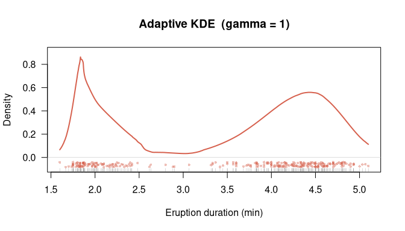

```r
plot(res_sv, xlab = "Eruption duration (min)")
```

### Estimating Uncertainty with Bootstrap

By setting the `nbs` parameter, you can instruct the function to perform a multi-core bootstrap resampling. For `sskernel`, this is a standard non-parametric bootstrap. For `ssvkernel`, it utilizes a Poisson bootstrap suited for point processes.

When bootstrap intervals are calculated, the S3 `plot()` method automatically overlays a 90% confidence band (between the 5th and 95th percentiles).

```r
# Run 300 bootstrap iterations using 2 cores
res_boot <- sskernel(x_data, nbs = 300)
print(res_boot)
```

```
#> Shimazaki-Shinomoto Kernel Density Estimation
#> ----------------------------------------------
#> Optimal Bandwidth: 0.1103
#> Grid Points:       1000
#> Bootstrap CI:      90%  ( 300 samples)
```

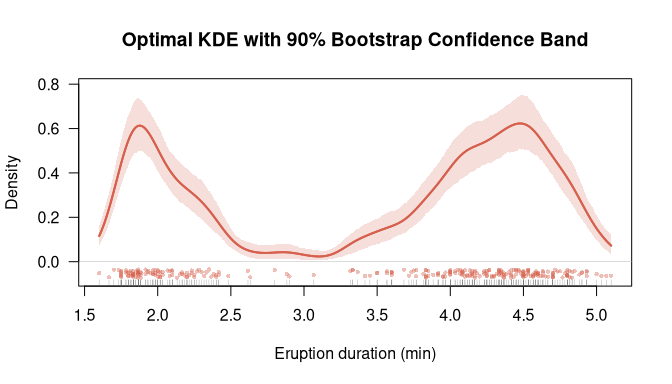

```r
# The plot function automatically detects and renders the confb95 band
plot(res_boot,
     main = "Optimal KDE with 90% Bootstrap Confidence Band",
     xlab = "Eruption duration (min)",
     col = "#d6604d",
     band_col = adjustcolor("#d6604d", alpha.f = 0.2))
```

```r
res_sv_boot <- ssvkernel(x_data, nbs = 300, WinFunc = "Gauss")

print(res_sv_boot)
```

```
#> Shimazaki-Shinomoto Adaptive Kernel Density Estimation
#> -------------------------------------------------------
#> Optimal Stiffness (gamma): 0.9947
#> Grid Points:               1000
#> Bandwidth Range:           0.0490827 -- 0.2415164
#> Bootstrap CI:              90%  ( 300 samples)
```

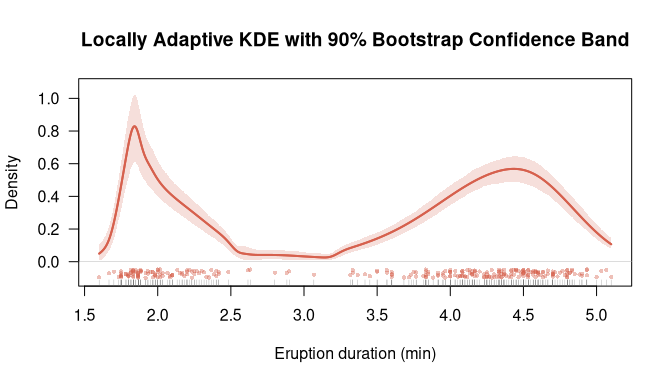

```r
# The plot function automatically detects and renders the confb95 band
plot(res_sv_boot,
     main = "Locally Adaptive KDE with 90% Bootstrap Confidence Band",
     xlab = "Eruption duration (min)",
     col = "#d6604d",
     band_col = adjustcolor("#d6604d", alpha.f = 0.2))
```

*Note: The raw density values for every bootstrap iteration are preserved in the `yb` matrix inside the returned object, giving you full flexibility to calculate custom percentiles if needed.*

## 3. Optimal 2D Density Estimation

When analyzing bivariate relationships, the package offers both grid-based histograms and smooth kernel density estimators.

### 2D Histogram: `sshist_2d`

Solves the X and Y bin-count problem simultaneously using the same MISE cost function extended to two dimensions.

**Complete Parameter List:**

- `x`: Numeric vector for X coordinates, or a 2-column matrix/data.frame containing X and Y.
- `y`: Numeric vector for Y coordinates (ignored if `x` is a matrix).
- `n_min`: Integer. Minimum number of bins per axis (default `2`).
- `n_max`: Integer or `NULL`. Maximum number of bins per axis (default `200`). Automatically clamped to the data resolution limit.

```r
res_2d <- sshist_2d(faithful$waiting, faithful$eruptions)
print(res_2d)
```

```
#> Shimazaki-Shinomoto 2D Histogram Optimization
#> ---------------------------------------------
#> Optimal Bins X:   9
#> Optimal Bins Y:   20
#> Bin Width X:      5.889
#> Bin Width Y:      0.175
```

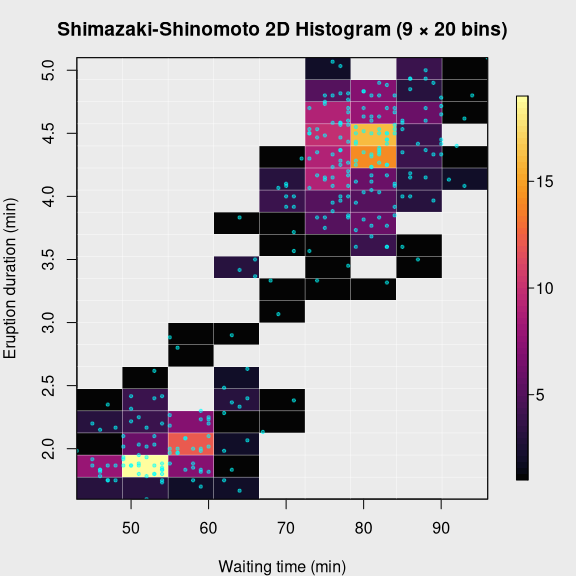

```r
# plot() renders the optimal 2D histogram as a heatmap
plot(res_2d, xlab = "Waiting time (min)", ylab = "Eruption duration (min)")
```

### 2D Kernel Density: `sskernel2d` and `ssvkernel2d`

**Complete Parameter List:**

- `x`: Numeric vector for X coordinates, or a 2-column matrix containing X and Y.
- `y`: Numeric vector for Y coordinates (required if `x` is a vector).
- `W` *(sskernel2d only)*: Optional numeric vector of bandwidths to evaluate. If `NULL`, a smart log-spaced grid is used.
- `n_grid`: Integer specifying the resolution of the output density matrix (default `100`).
- `sensitivity` *(ssvkernel2d only)*: Numeric scalar controlling the sensitivity of local bandwidths to the pilot density. A value of `0.5` (default) corresponds to Abramson’s inverse square-root law.
- `ncores`: Integer. Number of OpenMP threads to use for the heavy C++ 2D grid computations.

**`sskernel2d`** finds the globally optimal isotropic bandwidth. To handle variables on different scales, the data are internally standardized before optimization; the resulting bandwidth is then rescaled back to each original axis.

```r
df <- faithful   # eruptions: ~2-5 min,  waiting: ~40-90 min

# Fixed global bandwidth (C++ accelerated)
res_2d_fixed <- sskernel2d(df$eruptions, df$waiting, n_grid = 256)
print(res_2d_fixed)
```

```
#> Shimazaki-Shinomoto 2D Kernel Density Estimation
#> -------------------------------------------------
#> Optimal Bandwidth X: 0.1947
#> Optimal Bandwidth Y: 2.319
#> Grid Size:           256 x 256
```

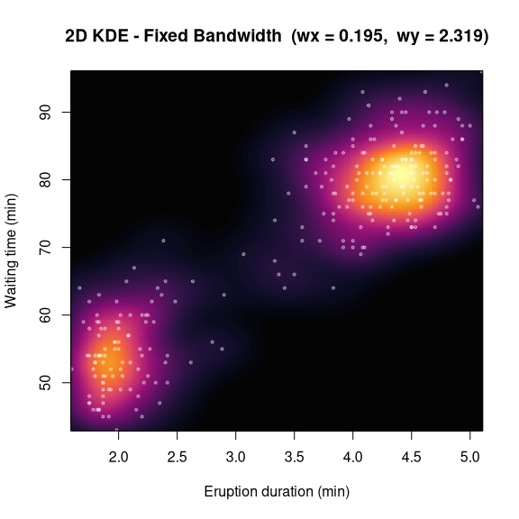

```r
plot(res_2d_fixed,
     xlab = "Eruption duration (min)",
     ylab = "Waiting time (min)")
```

**`ssvkernel2d`** wraps `sskernel2d` as a pilot estimator and applies Abramson’s square-root law to derive a per-point local bandwidth.

```r
# Locally adaptive bandwidth (Abramson's method)
res_2d_adap <- ssvkernel2d(df$eruptions, df$waiting,
                            n_grid = 256, sensitivity = 0.5)
print(res_2d_adap)
```

```
#> Shimazaki-Shinomoto Adaptive 2D Kernel Density Estimation
#> ----------------------------------------------------------
#> Pilot Bandwidth X:   0.1947
#> Pilot Bandwidth Y:   2.319
#> Grid Size:           256 x 256
#> Lambda Range:        0.653 -- 3.33   (median 0.921 )
```

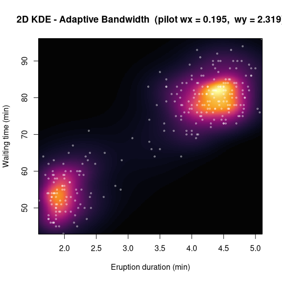

```r
plot(res_2d_adap,
     xlab = "Eruption duration (min)",
     ylab = "Waiting time (min)")
```

## References

- Shimazaki, H. and Shinomoto, S. (2007). A method for selecting the bin size of a time histogram. *Neural Computation*, **19**(6), 1503–1527. [doi:10.1162/neco.2007.19.6.1503](https://doi.org/10.1162/neco.2007.19.6.1503)
- Shimazaki, H. and Shinomoto, S. (2010). Kernel bandwidth optimization in spike rate estimation. *Journal of Computational Neuroscience*, **29**(1–2), 171–182. [doi:10.1007/s10827-009-0180-4](https://doi.org/10.1007/s10827-009-0180-4)
- https://www.neuralengine.org/res/histogram.html
- https://www.neuralengine.org/res/kernel.html
- https://github.com/shimazaki/density_estimation
- https://s-shinomoto.com/toolbox/sshist/hist.html